# Lab 6: Causal Inference (Part II)

Author

Feng Qiu, Liyuan Xuan

Published

November 24, 2025

The development of Lab 6 is based on Chapter 5, 6 and 9 of the textbook *[Causal Inference: The Mixtape](https://mixtape.scunning.com/05-matching_and_subclassification)* by Scott Cunningham.

## 1 Preparation

```r
options(scipen = 9999) # turn off scientific notation

library(dplyr)

# package for RDD
library(ggplot2)
library(rdrobust)
library(rddensity)

# package for DiD and event study
library(fixest)
```

## 2 Matching and Subclassification

### 2.1 Data Generation

For this section, we will first generate a sample dataset of 1,000 students, such that:

- Students are categorized into three performance groups: “High”, “Medium”, and “Low”.
- Treatment “scholarship” is randomly assigned at a constant probability to students of the same performance groups.
- Scholarship adds a constant 10 points for everyone to exam scores.

Then, given prior knowledge on how “scholarship” is assigned, we will explain how subclassification and matching can approximate the ATE and ATT.

```r
set.seed(100)

performance <- sample(
  c("Low", "Medium", "High"),
  size    = 1000,
  replace = TRUE,
  prob    = c(0.3, 0.4, 0.3)  # distribution of the performance
)

df_matching <- data.frame(performance)

df_matching <- df_matching %>% mutate(
   p_scholarship = case_when(
      performance == "Low"    ~ 0.10,
      performance == "Medium" ~ 0.30,
      performance == "High"   ~ 0.60  # higher performance has larger probability to receive scholarship
    ),
   scholarship = rbinom(1000, 1, p_scholarship)
)

u <- rnorm(1000, 0, 5) # noise

df_matching <- df_matching %>% mutate(
  score0 = case_when(
    performance == "Low"    ~ 60 + 10 * (-1) + u,
    performance == "Medium" ~ 60 + 10 * (0) + u,
    performance == "High"   ~ 60 + 10 * (1) + u,
  ),
  score1 = score0 + 10,
  score_ob = ifelse(scholarship == 1, score1, score0)
)

true_ATE <- mean(df_matching$score1 - df_matching$score0)
true_ATE
```

```
[1] 10
```

```r
true_ATT <- mean(df_matching$score1[df_matching$scholarship == 1] - df_matching$score0[df_matching$scholarship == 1])
true_ATT
```

```
[1] 10
```

```r
summary(df_matching)
```

```
 performance        p_scholarship     scholarship        score0
 Length:1000        Min.   :0.1000   Min.   :0.000   Min.   :37.36
 Class :character   1st Qu.:0.1000   1st Qu.:0.000   1st Qu.:52.77
 Mode  :character   Median :0.3000   Median :0.000   Median :59.96
                    Mean   :0.3234   Mean   :0.329   Mean   :59.73
                    3rd Qu.:0.6000   3rd Qu.:1.000   3rd Qu.:66.79
                    Max.   :0.6000   Max.   :1.000   Max.   :83.43
     score1         score_ob
 Min.   :47.36   Min.   :37.36
 1st Qu.:62.77   1st Qu.:53.56
 Median :69.96   Median :62.63
 Mean   :69.73   Mean   :63.02
 3rd Qu.:76.79   3rd Qu.:72.07
 Max.   :93.43   Max.   :93.43
```

```r
table(df_matching$performance, df_matching$scholarship)
```

```
           0   1
  High   121 171
  Low    285  36
  Medium 265 122
```

### 2.2 Conditional Independence Assumption

Recall that, the Independence Assumption assumes perfect randomization in treatment assignment, which is rare in the real world. Instead, we can relax the assumption to have treatment being randomly assigned among individuals sharing similar characteristics, such as “performance”.

$$(Y^1, Y^0) \perp\!\!\!\perp D|X$$

### 2.3 Subclassification

```r
subclass <- df_matching %>% group_by(performance) %>% summarise(
  N = n(),
  N1 = sum(scholarship),
  N0 = N - N1,
  EY_1 = mean(score_ob[scholarship == 1]),
  EY_0 = mean(score_ob[scholarship == 0]),
  delta_x = EY_1 - EY_0
  ) %>%
  ungroup()

subclass <- subclass %>% mutate(
  prop = N / sum(N),
  prop.treat = N1 / sum(N1)
)
subclass
```

| performance | N | N1 | N0 | EY_1 | EY_0 | delta_x | prop | prop.treat |
| --- | --- | --- | --- | --- | --- | --- | --- | --- |
| High | 292 | 171 | 121 | 79.23381 | 70.17592 | 9.057893 | 0.292 | 0.5197568 |
| Low | 321 | 36 | 285 | 61.65107 | 49.95220 | 11.698876 | 0.321 | 0.1094225 |
| Medium | 387 | 122 | 265 | 69.79424 | 60.41417 | 9.380069 | 0.387 | 0.3708207 |

```r
ATE_sub <- sum(subclass$delta_x * subclass$prop)
ATE_sub
```

```
[1] 10.03033
```

```r
ATT_sub <- sum(subclass$delta_x * subclass$prop.treat)
ATT_sub
```

```
[1] 9.466345
```

### 2.4 Regression with Controls on “performance”

Regression estimates can approximate the “true” treatment effects if we control “performance”.

```r
lm_noX   <- lm(score_ob ~ scholarship, data = df_matching)
lm_withX <- lm(score_ob ~ scholarship + performance, data = df_matching)

summary(lm_noX)
```

```
Call:
lm(formula = score_ob ~ scholarship, data = df_matching)

Residuals:
     Min       1Q   Median       3Q      Max
-21.7554  -6.0686  -0.2178   6.3084  24.3817

Coefficients:
            Estimate Std. Error t value            Pr(>|t|)
(Intercept)  57.7309     0.3324  173.67 <0.0000000000000002 ***
scholarship  16.0786     0.5795   27.74 <0.0000000000000002 ***
---
Signif. codes:  0 '***' 0.001 '**' 0.01 '*' 0.05 '.' 0.1 ' ' 1

Residual standard error: 8.611 on 998 degrees of freedom
Multiple R-squared:  0.4354,    Adjusted R-squared:  0.4349
F-statistic: 769.7 on 1 and 998 DF,  p-value: < 0.00000000000000022
```

```r
summary(lm_withX)
```

```
Call:
lm(formula = score_ob ~ scholarship + performance, data = df_matching)

Residuals:
     Min       1Q   Median       3Q      Max
-14.4627  -3.5061   0.0558   3.1644  15.6426

Coefficients:
                  Estimate Std. Error t value            Pr(>|t|)
(Intercept)        69.8261     0.3558  196.26 <0.0000000000000002 ***
scholarship         9.6553     0.3592   26.88 <0.0000000000000002 ***
performanceLow    -19.6447     0.4315  -45.53 <0.0000000000000002 ***
performanceMedium  -9.4987     0.3923  -24.21 <0.0000000000000002 ***
---
Signif. codes:  0 '***' 0.001 '**' 0.01 '*' 0.05 '.' 0.1 ' ' 1

Residual standard error: 4.903 on 996 degrees of freedom
Multiple R-squared:  0.8173,    Adjusted R-squared:  0.8167
F-statistic:  1485 on 3 and 996 DF,  p-value: < 0.00000000000000022
```

### 2.5 Exact Matching

#### 2.5.1 Calculate Manually

Recall that, with multiple matched units, the formulas for calculating ATT and ATE are:

$$\hat{\delta}_{ATT}=\frac{1}{N_T}\sum_{D_i=1}(Y_i-[\frac{1}{M}\sum_{m=1}^MY_{jm(1)}])$$
$$\hat{\delta}_{ATE}=\frac{1}{N}\sum_{i=1}^{N}(2D_i-1)(Y_i-[\frac{1}{M}\sum_{m=1}^MY_{jm(i)}])$$

```r
match_exact_manual <- df_matching %>% group_by(performance) %>% mutate(
  mean_treat = mean(score_ob[scholarship == 1]),
  mean_control = mean(score_ob[scholarship == 0]),

  mean_match = ifelse(scholarship == 1, mean_control, mean_treat), # since we have multiple units matched per unit

  diff_ATT = ifelse(scholarship == 1, score_ob - mean_match, NA),
  diff_ATE = (2 * scholarship - 1) * (score_ob - mean_match)
  ) %>%
  ungroup()

ATT_exact_manual <- mean(match_exact_manual$diff_ATT, na.rm = T)
ATE_exact_manual <- mean(match_exact_manual$diff_ATE)

c(ATT_manual = ATT_exact_manual, ATE_manual = ATE_exact_manual)
```

```
ATT_manual ATE_manual
  9.466345  10.030330
```

**Note**

Since we have prior knowledge on how the treatment “scholarship” is assigned conditionally based on the discrete “performance”, when performing exact matching, we would have the same results as subclassification.

#### 2.5.2 Regression

```r
lm(score_ob ~ scholarship + performance, data = df_matching)
```

```
Call:
lm(formula = score_ob ~ scholarship + performance, data = df_matching)

Coefficients:
      (Intercept)        scholarship     performanceLow  performanceMedium
           69.826              9.655            -19.645             -9.499
```

## 3 Regression Discontinuity Design (RDD)

### 3.1 Data Generation

For this section, we will also work on a simulated data specified below, highlighting a school financial assistance program distributing assistance to students achieving a test score above 120. Before we generate a more “realistic” scenario on how the program would improve students’ earnings after graduation, we will use the earnings in absence of treatment for illustration.

```r
set.seed(100)

df_rdd <- data.frame(score = rnorm(1000, 100, 50)) %>% mutate(score = ifelse(score < 0, 0, score)) %>%
  filter(score <= 240)

u <- rnorm(nrow(df_rdd), 0, 1000) # noise

df_rdd <- df_rdd %>%
  mutate(
    D  = ifelse(score > 120, 1, 0), # policy cutoff at score = 120
    score2 = score * score,
    earn0 = 10000 + 0 * D - 100 * score + score2 + u,

    score_center = score - 120,
    score_center2 = score_center * score_center
  )
```

### 3.2 Estimation

#### 3.2.1 Global Least Squares Regressions

##### 3.2.1.1 Linear Regression

We begin with estimating a linear regression below,

$$Earn_i = \alpha + \delta D_i + \beta_{1} \tilde{Score_i} + \gamma_{1}(D_i * \tilde{Score_i}) + \epsilon_i, \text{where } \tilde{Score_i} = Score_i - 120$$

Left of cutoff ($D_i=0$):

- $\text{intercept}=\alpha$
- $\text{slope}=\beta$

Right of cutoff ($D_i=1$):

- $\text{intercept}=\alpha + \tau$
- $\text{slope}=\beta + \gamma$

Therefore, the coefficient of $D_i$, $\tau$, should capture the treatment effect. This is the “jump” at the cutoff score, since $(\alpha + \tau) - \alpha = \tau$

```r
rdd_linear <- lm(earn0 ~ D + score_center + D:score_center, data = df_rdd)
summary(rdd_linear)
```

```
Call:
lm(formula = earn0 ~ D + score_center + D:score_center, data = df_rdd)

Residuals:
    Min      1Q  Median      3Q     Max
-3601.8 -1038.6  -153.4   916.9  4349.0

Coefficients:
                Estimate Std. Error t value             Pr(>|t|)
(Intercept)    10259.818    100.393 102.197 < 0.0000000000000002 ***
D                949.559    158.715   5.983        0.00000000306 ***
score_center      25.351      1.722  14.722 < 0.0000000000000002 ***
D:score_center   205.968      3.379  60.963 < 0.0000000000000002 ***
---
Signif. codes:  0 '***' 0.001 '**' 0.01 '*' 0.05 '.' 0.1 ' ' 1

Residual standard error: 1435 on 993 degrees of freedom
Multiple R-squared:  0.9458,    Adjusted R-squared:  0.9457
F-statistic:  5779 on 3 and 993 DF,  p-value: < 0.00000000000000022
```

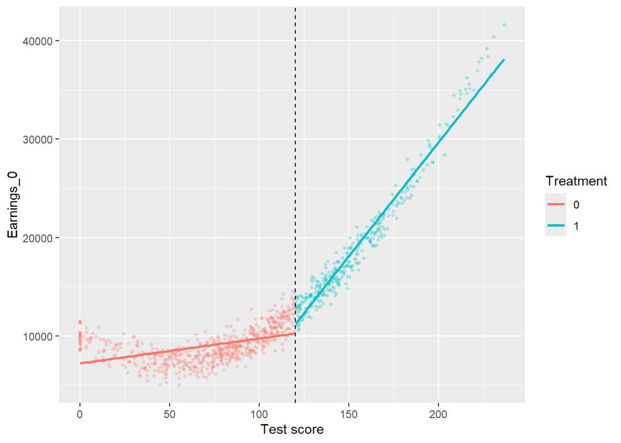

```r
ggplot(df_rdd, aes(x = score, y = earn0, color = factor(D))) + geom_point(alpha = 0.25, size = 0.9) +
  geom_smooth(data = df_rdd %>% filter(score <= 120), method = "lm", formula = y ~ x, se = FALSE) +
  geom_smooth(data = df_rdd %>% filter(score > 120),  method = "lm", formula = y ~ x, se = FALSE) +
  geom_vline(xintercept = 120, linetype = "dashed") +
  labs(x = "Test score", y = "Earnings_0", color = "Treatment")
```

##### 3.2.1.2 Polynomial Regression

Because the “true” data-generating process is nonlinear, a global linear regression will incorrectly produce a treatment effect even when the true effect is zero. As a result, polynomial terms are often added to the regression.

$$Earn_i = \alpha + \delta D_i + \beta_{1} \tilde{Score_i} + \gamma_{1}(D_i * \tilde{Score_i}) + \beta_{2} \tilde{Score_i}^2 + \gamma_{2}(D_i * \tilde{Score_i}^2) + \epsilon_i$$

```r
rdd_poly <- lm(earn0 ~ D + score_center + D:score_center + score_center2 + D:score_center2, data = df_rdd)
summary(rdd_poly)
```

```
Call:
lm(formula = earn0 ~ D + score_center + D:score_center + score_center2 +
    D:score_center2, data = df_rdd)

Residuals:
    Min      1Q  Median      3Q     Max
-2947.8  -685.3     7.3   615.1  3166.6

Coefficients:
                   Estimate  Std. Error t value            Pr(>|t|)
(Intercept)     12492.09084   100.94052 123.757 <0.0000000000000002 ***
D                 -92.34965   154.05991  -0.599               0.549
score_center      144.55992     4.12170  35.073 <0.0000000000000002 ***
score_center2       1.03075     0.03415  30.182 <0.0000000000000002 ***
D:score_center      0.05950     7.43429   0.008               0.994
D:score_center2    -0.08593     0.07241  -1.187               0.236
---
Signif. codes:  0 '***' 0.001 '**' 0.01 '*' 0.05 '.' 0.1 ' ' 1

Residual standard error: 982.1 on 991 degrees of freedom
Multiple R-squared:  0.9747,    Adjusted R-squared:  0.9746
F-statistic:  7632 on 5 and 991 DF,  p-value: < 0.00000000000000022
```

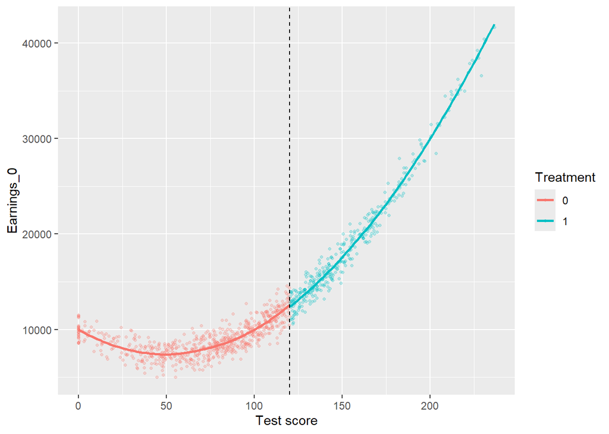

```r
ggplot(df_rdd, aes(x = score, y = earn0, color = factor(D))) + geom_point(alpha = 0.25, size = 0.9) +
  geom_smooth(data = df_rdd %>% filter(score <= 120), method = "loess", se = FALSE) +
  geom_smooth(data = df_rdd %>% filter(score > 120),  method = "loess", se = FALSE) +
  geom_vline(xintercept = 120, linetype = "dashed") +
  labs(x = "Test score", y = "Earnings_0", color = "Treatment")
```

##### 3.2.1.3 Assigning “True” Treatment Effect

Knowing the “true” treatment effect is +5,000 and the data generation process is non-linear, we estimate the following polynomial regression.

```r
df_rdd <- df_rdd %>%
  mutate(
    earn1 = earn0 + 5000,
    earn_ob = ifelse(D == 1, earn1, earn0),
    score_center3 = score_center * score_center * score_center
  )

rdd_ploy_ob <- lm(earn_ob ~ D + score_center + D:score_center + score_center2 + D:score_center2, data = df_rdd)
summary(rdd_ploy_ob)
```

```
Call:
lm(formula = earn_ob ~ D + score_center + D:score_center + score_center2 +
    D:score_center2, data = df_rdd)

Residuals:
    Min      1Q  Median      3Q     Max
-2947.8  -685.3     7.3   615.1  3166.6

Coefficients:
                   Estimate  Std. Error t value            Pr(>|t|)
(Intercept)     12492.09084   100.94052 123.757 <0.0000000000000002 ***
D                4907.65035   154.05991  31.855 <0.0000000000000002 ***
score_center      144.55992     4.12170  35.073 <0.0000000000000002 ***
score_center2       1.03075     0.03415  30.182 <0.0000000000000002 ***
D:score_center      0.05950     7.43429   0.008               0.994
D:score_center2    -0.08593     0.07241  -1.187               0.236
---
Signif. codes:  0 '***' 0.001 '**' 0.01 '*' 0.05 '.' 0.1 ' ' 1

Residual standard error: 982.1 on 991 degrees of freedom
Multiple R-squared:  0.9855,    Adjusted R-squared:  0.9855
F-statistic: 1.349e+04 on 5 and 991 DF,  p-value: < 0.00000000000000022
```

#### 3.2.2 Local Least Squares Regressions (Nonparametric Kernels)

The recent papers suggest to estimate local linear nonparametric regressions with kernel method. A user-written package “rdrobust” implement estimation

```r
rdr <- rdrobust(y = df_rdd$earn_ob, x = df_rdd$score, c = 120)
summary(rdr)
```

```
Sharp RD estimates using local polynomial regression.

Number of Obs.                  997
BW type                       mserd
Kernel                   Triangular
VCE method                       NN

Number of Obs.                  641          356
Eff. Number of Obs.             257          216
Order est. (p)                    1            1
Order bias  (q)                   2            2
BW est. (h)                  34.750       34.750
BW bias (b)                  60.721       60.721
rho (h/b)                     0.572        0.572
Unique Obs.                     614          356

=====================================================================
                   Point    Robust Inference
                Estimate         z     P>|z|      [ 95% C.I. ]
---------------------------------------------------------------------
     RD Effect  4835.592    19.248     0.000  [4272.390 , 5241.136]
=====================================================================
```

**Note**

The package also provides a way to visualize your data. Try `rdplot(y = df_rdd$earn_ob, x = df_rdd$score, c = 120)`.

### 3.3 Diagnoses and Tests

#### 3.3.1 Continuity Assumption

Our simulated data allows us to check if the continuity assumption holds in the absence of treatment.

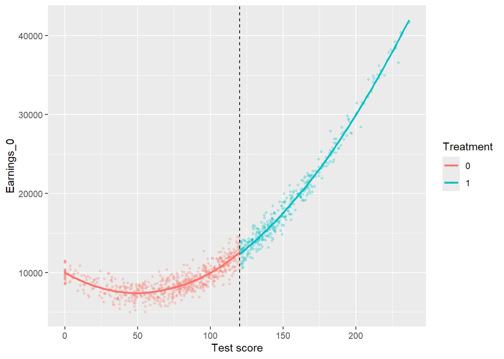

```r
ggplot(aes(score, earn0, colour = factor(D)), data = df_rdd) +
    geom_point(alpha = 0.25, size = 0.9) + geom_vline(xintercept = 120, linetype = "dashed") +
    geom_smooth(data = df_rdd %>% filter(score <= 120), method = "loess", se = FALSE) +
    geom_smooth(data = df_rdd %>% filter(score > 120),  method = "loess", se = FALSE) +
    labs(x = "Test score", y = "Earnings_0", color = "Treatment")
```

#### 3.3.2 McCreary’s Density Test

The McCreary density test is used to test if the density of running variable is continous at cutoff.

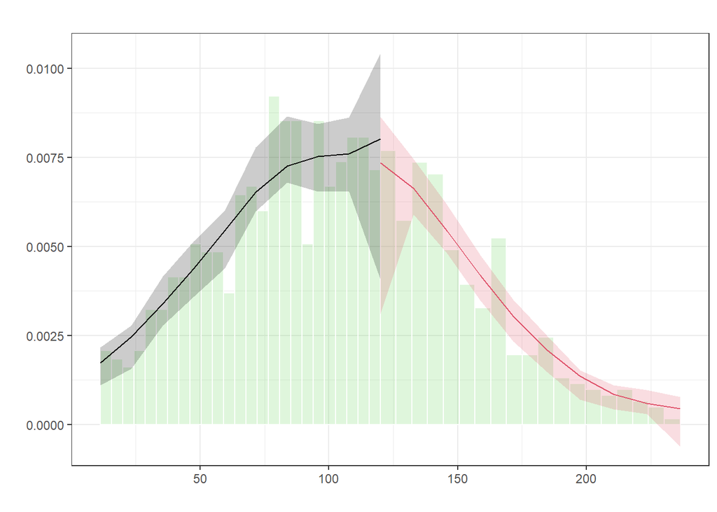

```r
density <- rddensity(df_rdd$score, c = 120)
density_plot <- rdplotdensity(density, df_rdd$score)
```

#### 3.3.3 Placebo Tests

Placebo tests can be used to check whether there is a treatment ‘effect’ away from the true cutoff.

```r
rdr_placebo <- rdrobust(y = df_rdd$earn_ob, x = df_rdd$score, c = 100)
summary(rdr_placebo)
```

```
Sharp RD estimates using local polynomial regression.

Number of Obs.                  997
BW type                       mserd
Kernel                   Triangular
VCE method                       NN

Number of Obs.                  490          507
Eff. Number of Obs.              73           82
Order est. (p)                    1            1
Order bias  (q)                   2            2
BW est. (h)                  10.766       10.766
BW bias (b)                  24.774       24.774
rho (h/b)                     0.435        0.435
Unique Obs.                     463          507

=====================================================================
                   Point    Robust Inference
                Estimate         z     P>|z|      [ 95% C.I. ]
---------------------------------------------------------------------
     RD Effect  -202.233    -0.071     0.943  [-679.478 , 631.941]
=====================================================================
```

## 4 Difference-in-Differences (DiD)

### 4.1 Data Generation

To show the DiD estimator could correctly capture the treatment effect, we again use the simulated data. We propose a scenario for two provinces A and B between the years 2000 and 2020. Given that unemployment rates is relatively higher in province A, it decides to implement a job-training program in 2010 to assist local workers. As designed, the true treatment effect of such program on unemployment rates in province A is -2.

```r
set.seed(100)

years <- 2000:2020
provinces <- c("A", "B")

df_did <- expand.grid(year = years, province = provinces)

df_did <- df_did %>%
  mutate(
    unemp_base = ifelse(province == "A", 13, 10),
    trend = -0.1 * (year - 2000),
    unemp_0 = unemp_base + trend + rnorm(n(), 0, 0.05),

    jt_effect = ifelse(province == "A" & year >= 2010, -2, 0),
    unemp_ob = unemp_0 + jt_effect
  )
```

### 4.2 Simple DiD

#### 4.2.1 Set Up

In a typical simple 2x2 DiD setup, we usually begin by generating two dummy variables “treat” (for the treatment group) and “post” (for the post-treatment period), then their interaction term.

```r
df_did <- df_did %>% mutate(
  post = ifelse(year >= 2010, 1, 0),
  treat = ifelse(province == "A", 1, 0),
  post_treat = post * treat
)
```

#### 4.2.2 Calculating the DiD Estimator

The difference in difference estimator calculate the differences as below:

$$\hat{\delta}^{2\times 2}_{kU} = (E[Y_k|\text{Post}] - E[Y_k|\text{Pre}]) - (E[Y_U|\text{Post}] - E[Y_U|\text{Pre}])$$

```r
difference_A <- mean(df_did$unemp_ob[df_did$post == 1 & df_did$treat == 1]) -
                mean(df_did$unemp_ob[df_did$post == 0 & df_did$treat == 1])

difference_B <- mean(df_did$unemp_ob[df_did$post == 1 & df_did$treat == 0]) -
                mean(df_did$unemp_ob[df_did$post == 0 & df_did$treat == 0])

diff_in_diff <- difference_A - difference_B
diff_in_diff
```

```
[1] -2.015802
```

#### 4.2.3 Non-parallel Trends Bias

The key assumption that allows the DiD estimator to identify the ATT is the assumption of parallel trend. Conveniently, in our simulated data, we know such assumption would hold.

$$\begin{aligned}
\hat{\delta}^{2\times 2}_{kU} &= \Big( E[Y_k^1|\text{Post}] - E[Y_k^0|\text{Post}] \Big) +
\bigg[
\Big( E[Y_k^0|\text{Post}] - E[Y_k^0|\text{Pre}] \Big) - \Big( E[Y_U^0|\text{Post}] - E[Y_U^0|\text{Pre}] \Big)
\bigg] \\
&= \text{ATT} + \text{Non-parallel bias in 2x2 case}
\end{aligned}$$

```r
NP_bias_term1 <- mean(df_did$unemp_0[df_did$post == 1 & df_did$treat == 1]) -
                 mean(df_did$unemp_0[df_did$post == 0 & df_did$treat == 1])

NP_bias_term2 <- mean(df_did$unemp_0[df_did$post == 1 & df_did$treat == 0]) -
                 mean(df_did$unemp_0[df_did$post == 0 & df_did$treat == 0])

NP_bias <- NP_bias_term1 - NP_bias_term2
NP_bias
```

```
[1] -0.01580178
```

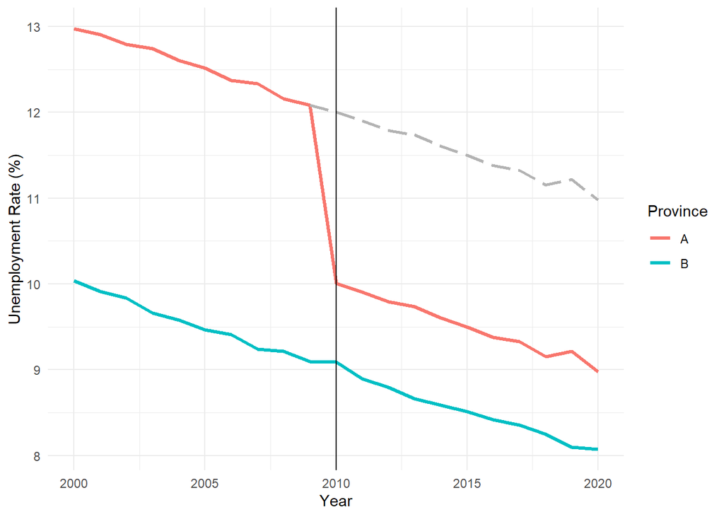

```r
ggplot(df_did) +
  geom_line(aes(x = year, y = unemp_ob, color = province), linewidth = 1.2) +
  geom_line(data = filter(df_did, province == "A" & year >= 2009), aes(x = year, y = unemp_0), linetype = "longdash", linewidth = 1, color = "grey70") +
  geom_vline(xintercept = 2010) +
  labs(
    x = "Year",
    y = "Unemployment Rate (%)",
    color = "Province"
  ) +
  theme_minimal()
```

#### 4.2.4 Regression

We can also utilize the dummy variables “treat” and “post” to estimate the DiD estimator via the regression below.

$$\text{unemp}_{it} = \alpha + \beta\text{Treat}_i+\gamma\text{Post}_t + \delta\bigg( \text{Post}_t \times \text{Treat}_i \bigg) + \epsilon_{it}$$

```r
did_simple <- lm(unemp_ob ~ treat + post + post_treat, data = df_did)
summary(did_simple)
```

```
Call:
lm(formula = unemp_ob ~ treat + post + post_treat, data = df_did)

Residuals:
     Min       1Q   Median       3Q      Max
-0.53054 -0.25742 -0.01078  0.26711  0.56726

Coefficients:
            Estimate Std. Error t value             Pr(>|t|)
(Intercept)   9.5453     0.1015  94.072 < 0.0000000000000002 ***
treat         3.0038     0.1435  20.933 < 0.0000000000000002 ***
post         -1.0247     0.1402  -7.309     0.00000000943498 ***
post_treat   -2.0158     0.1983 -10.167     0.00000000000215 ***
---
Signif. codes:  0 '***' 0.001 '**' 0.01 '*' 0.05 '.' 0.1 ' ' 1

Residual standard error: 0.3209 on 38 degrees of freedom
Multiple R-squared:  0.9599,    Adjusted R-squared:  0.9568
F-statistic: 303.6 on 3 and 38 DF,  p-value: < 0.00000000000000022
```

### 4.3 Event Study

#### 4.3.1 Expanding the Dataset

Now, we expand the data to include 4 cities in the provinces A and B. Again, the job training program is implemented in province A in 2010.

```r
set.seed(100)

cities <- c("a", "b", "c", "d")

df_did2 <- expand.grid(year = years, city = cities)

df_did2 <- df_did2 %>%
  mutate(
    unemp_base = case_when(city == "a" ~ 13, city == "b" ~ 11, city == "c" ~ 10, city == "d" ~ 7),
    trend = -0.1 * (year - 2000),
    unemp_0 = unemp_base + trend + rnorm(n(), 0, 0.05),
    province = ifelse(city == "a" | city == "b", "A", "B"),

    jt_effect = ifelse(province == "A" & year >= 2010, -2, 0),
    unemp_ob = unemp_0 + jt_effect
  )
```

#### 4.3.2 Estimation

For event study, we are estimating the regression below:

$$\text{unemp}_{it} = \sum_{j=-10}^{-2}\beta_j \bigg( \text{Treat}_i * \text{Before}_t \bigg) + \sum_{k=0}^{10}\beta_k \bigg( \text{Treat}_i * \text{After}_t \bigg) + \text{city}_{i} + \text{year}_t + \epsilon_{it}$$

- $\text{Treat}_i$ is the dummy variable that equals 1 for cities “a” or “b”.
- $\text{Before}_t$ is the dummy variable that equals 1 for each year before 2010 (the treatment year).
- $\text{After}_t$ is the dummy variable that equals 1 for each year after 2010 (the treatment year).
- $\text{city}_{i}$ and $\text{year}_t$ are the fixed effects on cities and years.

```r
df_did2 <- df_did2 %>%
    mutate(
        treat = ifelse(province == "A", 1, 0),
        event_time = year - 2010
    )

event_study <- feols(unemp_ob ~ i(event_time, treat, ref = -1) | city + year, data = df_did2)
summary(event_study)
```

```
OLS estimation, Dep. Var.: unemp_ob
Observations: 84
Fixed-effects: city: 4,  year: 21
Standard-errors: Clustered (city)
                       Estimate Std. Error    t value    Pr(>|t|)
event_time::-10:treat -0.074834   0.110939  -0.674551 0.548291285
event_time::-9:treat  -0.070231   0.030575  -2.297014 0.105276325
event_time::-8:treat  -0.013006   0.027330  -0.475889 0.666661025
event_time::-7:treat  -0.108447   0.066323  -1.635138 0.200534823
event_time::-6:treat  -0.065244   0.023375  -2.791177 0.068351937 .
event_time::-5:treat  -0.102520   0.066941  -1.531491 0.223159435
event_time::-4:treat  -0.068804   0.025421  -2.706596 0.073375335 .
event_time::-3:treat  -0.036587   0.078445  -0.466405 0.672705667
event_time::-2:treat  -0.037920   0.040804  -0.929336 0.421265525
event_time::0:treat   -2.060754   0.047070 -43.780787 0.000026230 ***
event_time::1:treat   -2.058177   0.129420 -15.903091 0.000540603 ***
event_time::2:treat   -2.012592   0.048715 -41.313319 0.000031209 ***
event_time::3:treat   -2.057329   0.089127 -23.083109 0.000178099 ***
event_time::4:treat   -2.035504   0.035557 -57.246962 0.000011742 ***
event_time::5:treat   -2.128244   0.039526 -53.844173 0.000014110 ***
event_time::6:treat   -2.043212   0.115354 -17.712589 0.000392341 ***
event_time::7:treat   -2.023294   0.033867 -59.742479 0.000010332 ***
event_time::8:treat   -2.052042   0.046958 -43.699428 0.000026377 ***
event_time::9:treat   -1.970680   0.092412 -21.324858 0.000225624 ***
event_time::10:treat  -1.979371   0.075051 -26.373777 0.000119594 ***
---
Signif. codes:  0 '***' 0.001 '**' 0.01 '*' 0.05 '.' 0.1 ' ' 1
RMSE: 0.04018     Adj. R2: 0.999261
                Within R2: 0.993453
```

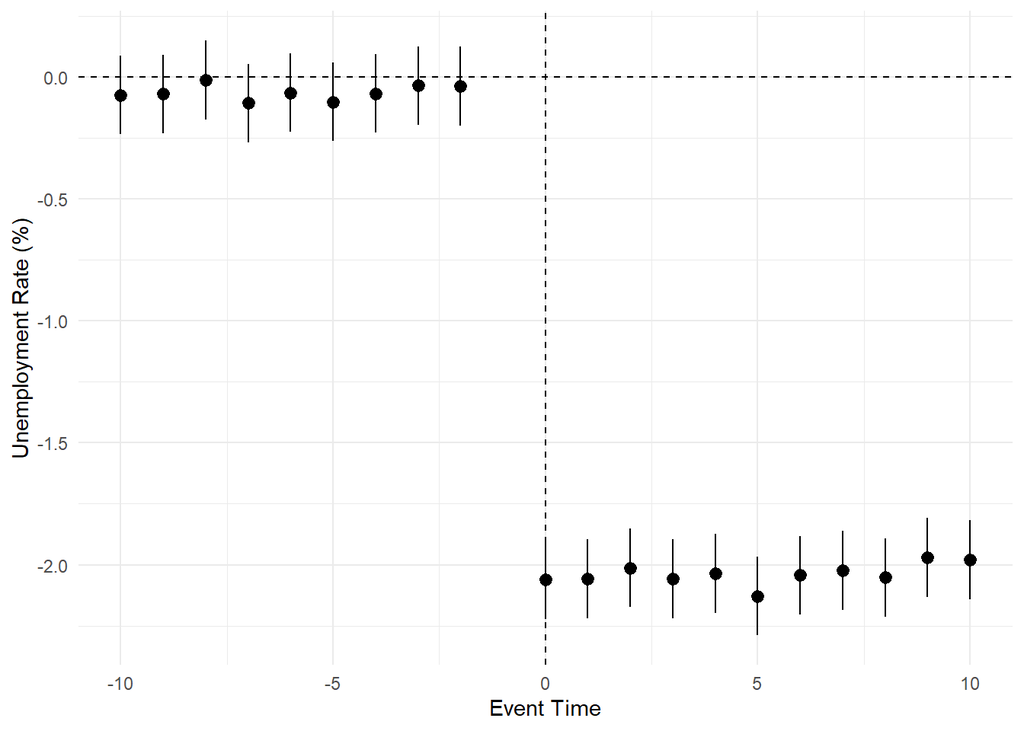

```r
# for visualization

event_study_plot <- data.frame(
  sd = c(event_study$coeftable$`Std. Error`),
  coef = c(event_study$coeftable$`Estimate`),
  label = c(-10, -9, -8, -7, -6, -5, -4, -3, -2, 0, 1, 2, 3, 4, 5, 6, 7, 8, 9, 10)
)

ggplot(data = event_study_plot,
       aes(x = label, y = coef, ymin = coef - 1.96 * sd, ymax = coef + 1.96 * sd)) +
  geom_pointrange() +
  labs(x = "Event Time", y = "Unemployment Rate (%)") +
  geom_hline(yintercept = 0, linetype = "dashed") +
  geom_vline(xintercept = 0, linetype = "dashed") +
  theme_minimal()
```

## 5 Exercise

### 5.1 Matching and Subclassification

Suppose the rating of “performance” (High/Medium/Low) is derived from a comprehensive index ranging between 0 and 100, explain in reality (having no prior knowledge on the data generation process) why we may have the “Curse of Dimensionality” problem.

### 5.2 Regression Discontinuity Design (RDD)

1. Use the linear regression as the example to explain why we need to center $Score_i$ first to identify $\delta$ as the treatment effect.
2. Estimate a similar polynomial regression but include the term with order 3?
3. To show robustness, perform multiple placebo tests at other alternative cutoffs.

### 5.3 Difference-in-Differences (DiD)

1. Use the results of the DiD regression (“did_simple”), calculate the average pre-treatment and post-treatment unemployment for province A and province B.
2. Perform a placebo test for the results “did_simple” using 2008 as the “treatment year”.
3. Use the expanded dataset “df_did2” to estimate a DiD regression.
4. In the visualization for results of the event study (“event_study”), is the parallel trends assumption satisfied?